# Forecast of healthcare needs for COVID-19 at Emory Healthcare

Report prepared by Dr. Ben Lopman (blopman@emory.edu) and Ms. Carol Liu (carol.liu@emory.edu)

April 05, 2020

## Summary

The following are predictions for health care needs for COVID-19 at Emory Healthcare. These predictions are based on a model of disease tranmission in the community, calibrated to Emory Heathcare data. **The projections can be updated frequently as new data become avialable.**

## Model results

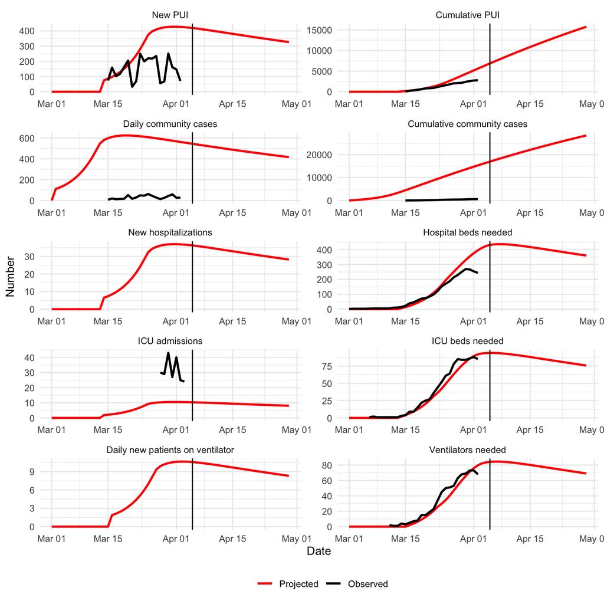

### Bed and resource needs table

| Date | New cases | Cumulative cases | New hospitalized | Hospitalized need | New ICU | ICU need | New on ventilator | Ventilator need | Gowns | Gloves |
| --- | --- | --- | --- | --- | --- | --- | --- | --- | --- | --- |
| 2020-04-04 | 551 | 16433 | 36 | 424 | 10 | 94 | 11 | 83 | 37693 | 10865 |
| 2020-04-05 | 545 | 16978 | 36 | 432 | 10 | 94 | 11 | 84 | 38282 | 11013 |
| 2020-04-06 | 539 | 17517 | 36 | 435 | 10 | 94 | 11 | 84 | 38533 | 11072 |
| 2020-04-07 | 533 | 18051 | 36 | 437 | 10 | 94 | 10 | 84 | 38603 | 11084 |
| 2020-04-08 | 527 | 18578 | 35 | 437 | 10 | 93 | 10 | 84 | 38563 | 11066 |
| 2020-04-09 | 522 | 19100 | 35 | 436 | 10 | 93 | 10 | 84 | 38439 | 11026 |
| 2020-04-10 | 516 | 19616 | 35 | 434 | 10 | 92 | 10 | 84 | 38251 | 10968 |
| 2020-04-11 | 510 | 20126 | 34 | 431 | 10 | 91 | 10 | 83 | 38014 | 10897 |
| 2020-04-12 | 505 | 20630 | 34 | 428 | 10 | 91 | 10 | 82 | 37739 | 10816 |
| 2020-04-13 | 499 | 21129 | 34 | 425 | 10 | 90 | 10 | 82 | 37437 | 10728 |
| 2020-04-14 | 494 | 21623 | 33 | 421 | 9 | 89 | 10 | 81 | 37114 | 10634 |
| 2020-04-15 | 488 | 22111 | 33 | 417 | 9 | 88 | 10 | 80 | 36775 | 10535 |
| 2020-04-16 | 483 | 22594 | 33 | 414 | 9 | 87 | 10 | 79 | 36426 | 10434 |
| 2020-04-17 | 477 | 23071 | 32 | 410 | 9 | 86 | 9 | 79 | 36068 | 10331 |
| 2020-04-18 | 472 | 23543 | 32 | 405 | 9 | 85 | 9 | 78 | 35706 | 10227 |
| 2020-04-19 | 467 | 24010 | 32 | 401 | 9 | 84 | 9 | 77 | 35340 | 10122 |
| 2020-04-20 | 462 | 24472 | 31 | 397 | 9 | 84 | 9 | 76 | 34973 | 10016 |
| 2020-04-21 | 456 | 24928 | 31 | 393 | 9 | 83 | 9 | 75 | 34605 | 9911 |
| 2020-04-22 | 451 | 25379 | 31 | 389 | 9 | 82 | 9 | 75 | 34237 | 9805 |
| 2020-04-23 | 446 | 25825 | 30 | 385 | 9 | 81 | 9 | 74 | 33871 | 9700 |
| 2020-04-24 | 441 | 26267 | 30 | 381 | 9 | 80 | 9 | 73 | 33506 | 9596 |
| 2020-04-25 | 436 | 26703 | 30 | 376 | 8 | 79 | 9 | 72 | 33143 | 9492 |
| 2020-04-26 | 431 | 27134 | 29 | 372 | 8 | 78 | 9 | 71 | 32783 | 9388 |
| 2020-04-27 | 427 | 27561 | 29 | 368 | 8 | 77 | 8 | 71 | 32425 | 9286 |
| 2020-04-28 | 422 | 27983 | 29 | 364 | 8 | 77 | 8 | 70 | 32070 | 9184 |
| 2020-04-29 | 417 | 28400 | 28 | 360 | 8 | 76 | 8 | 69 | 31718 | 9083 |
| 2020-04-30 | 412 | 28812 | 28 | 356 | 8 | 75 | 8 | 68 | 31369 | 8983 |
| 2020-05-01 | 408 | 29220 | 28 | 352 | 8 | 74 | 8 | 68 | 31023 | 8884 |

### Model Structure

An simple SEIR model in which infected persons have a probability of being undocumented or requiring different levels of haelthcare.

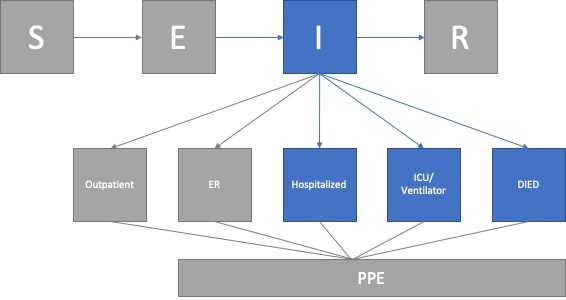

### Model inputs include:

- Greater Atlanta age distribution
- Proportion of COVID-19 cases who are hospitalized/require ICU/ventilation/die
- Time from
  - onset to hospitalization/ICU/ventilation/death
  - time in hospital/ICU/ventilation
- Epidemiologic parameters
  - R0
  - duration of incubation period
  - duration of symptomatic period
  - relative infectiousnes while incubating
- Intervention
  - Social distancing starting on March 12th

### Assumptions

Below are assumptions used in the predictions.

#### Hospitalization risk

We assume the age distribution of infected cases is equivalent to the age distribution of Atlanta

- 0-9 years old: 12%
- 10-19 years old: 11%
- 20-29 years old: 21%
- 30-39 years old: 17%
- 40-49 years old: 12%
- 50-59 years old: 11%
- 60-69 years old: 8%
- 70-79 years old: 5%
- 80+ years old: 3%

We assume that **among those that are infected**, risk of hospitalization is as follows. All values are proportions

- 0-9 years old: 0.10%
- 10-19 years old: 0.30%
- 20-29 years old: 1.20%
- 30-39 years old: 3.20%
- 40-49 years old: 4.90%
- 50-59 years old: 10.20%
- 60-69 years old: 16.60%
- 70-79 years old: 24.30%
- 80+ years old: 27.30%

#### Critical Care Risk

We assume that **among those that are hospitalized**, risk of critical care need is as follows.

- 0-9 years old: 5.00%
- 10-19 years old: 5.00%
- 20-29 years old: 5.00%
- 30-39 years old: 5.00%
- 40-49 years old: 6.30%
- 50-59 years old: 12.20%
- 60-69 years old: 27.40%
- 70-79 years old: 43.20%
- 80+ years old: 70.90%

#### Ventilation proportion

We assume that out of those in critical condition 80.0% in need of ventilation. These are best guess estimates from Washington in [this article](https://jamanetwork.com/journals/jama/fullarticle/2763485) where 15/21 (71%) required mechanical ventilation and 4/21 (19%) required noninvasitve positive pressure ventilation.

#### Length of hospital stay

We assume that a hospital stay is between 10 (low) and 20 (high) days and independent of age..

#### Lag times

The current assumption is that hospitalizations, critical care and ventilation numbers are assumed to lag infection by 12, 12, 14 days. Death is assumed to lag by 21 days. This is likely not true during the first few weeks, when a lot of diagnoses were only made after someone had already been in the hospital, or had died. Thus, for most of March, hospitalizations and deaths on a given day might be under-predicted. We assume that going forward, as test capacity keeps increasing, most individuals will be diagnosed before hospitalization or death.

#### Social distancing

We assume that the implementation of social distancing measures began in Atlanta on March 12th and that these measures collectively decreases transmission by 75%.

#### PPE assumptions

We preliminarily assumed the following for PPE:

- Each ICU patient receives 15 visits per day, needing 72 gowns and 30 pairs of gloves
- Each hospitalized patient received 9 visits per day, needing 72 gowns and 18 pairs of gloves
- Each PUI requires 1 gowns and 1 gloves per visit/test

### Next steps

We acknowledge that our predictions are preliminary. We will be fine-tuning our models to support the most critical needs of Emory Healthcare and to best fit the existing data. We plan to add the following features to the model in the coming days:

- Projected needs of swabs

To improve model calibration, the following information is requested:

- Dates of onset of cases
- New hospitalizations per day
- Newly on ventilator per day
- ICU/Ventilator capacity
- Hospital bed capacity

### Contributors

#### Emory SOM and RSPH

- Dr. Evan Anderson
- Dr. Kenneth Castro
- Dr. Allison Chamberlain
- Dr. Colleen Kraft
- Dr. Walt Orenstein
- Dr. Carlos Del Rio
- Dr. Nadine Rouphael
- Chad Robichaux
- Madison Vignes
- Paige Harton